# R Notebook

The purpose of this clustering study is to see how can we group the institution for students. It will not have a lot of clusters, it is just to see a few groups of institution that are close to each other and grouped together. The grouping is based on the attributes that are student related for an application.

```r
library(dplyr)
library(readxl)
college <- read_excel("C:/Users/Burcu Kolbay/Downloads/CollegeClusterData.xlsx")
glimpse(college)
```

```
## Observations: 5,709
## Variables: 27
## $ UNITID         <dbl> 100654, 100663, 100937, 104717, 142887, 143048,...
## $ INSTNM         <chr> "Alabama A & M University", "University of Alab...
## $ CITY           <chr> "Normal", "Birmingham", "Birmingham", "Phoenix"...
## $ STABBR         <chr> "AL", "AL", "AL", "AZ", "IL", "IL", "IL", "IL",...
## $ ZIP            <chr> "35762", "35294-0110", "35254", "85017", "60604...
## $ LATITUDE       <dbl> 34.7834, 33.5022, 33.5155, 33.5122, 41.8778, 41...
## $ LONGITUDE      <dbl> -86.5685, -86.8092, -86.8536, -112.1299, -87.62...
## $ LOCALE         <dbl> 12, 12, 12, 11, 11, 11, 13, 21, 21, 32, 13, 32,...
## $ CONTROL        <dbl> 1, 1, 2, 3, 3, 2, 2, 2, 1, 2, 1, 2, 3, 2, 3, 3,...
## $ DISTANCEONLY   <lgl> FALSE, FALSE, FALSE, FALSE, FALSE, FALSE, FALSE...
## $ PREDDEG        <dbl> 3, 3, 3, 3, 3, 3, 3, 3, 1, 4, 2, 3, 2, 3, 1, 1,...
## $ TUITFTE        <dbl> 9063, 9033, 11928, 10748, 24434, 28093, 17277, ...
## $ AVGFACSAL      <dbl> 7079, 10170, 7513, 5473, 4136, 9208, 7186, 7064...
## $ ADM_RATE       <dbl> 0.8989, 0.8673, 0.6422, 0.5480, 0.9300, 0.7184,...
## $ SAT_AVG        <dbl> 823, 1146, 1177, NA, NA, 1065, NA, 1011, NA, NA...
## $ UGDS           <dbl> 4051, 11200, 1181, 34643, 406, 2641, 2504, 3236...
## $ UGDS_WHITE     <dbl> 0.0279, 0.5987, 0.8103, 0.4427, 0.5394, 0.4559,...
## $ UGDS_BLACK     <dbl> 0.9501, 0.2590, 0.0940, 0.2075, 0.1232, 0.0299,...
## $ UGDS_HISP      <dbl> 0.0089, 0.0258, 0.0305, 0.1452, 0.2488, 0.0629,...
## $ UGDS_ASIAN     <dbl> 0.0022, 0.0518, 0.0390, 0.0437, 0.0394, 0.1253,...
## $ IND_INC_PCT_LO <chr> "0.947019868", "0.701354241", "1", "0.644696731...
## $ IND_INC_PCT_M1 <chr> "PrivacySuppressed", "0.142551675", "0", "0.129...
## $ IND_INC_PCT_M2 <chr> "PrivacySuppressed", "0.086956522", "0", "0.110...
## $ IND_INC_PCT_H1 <chr> "PrivacySuppressed", "0.05274412", "0", "0.0728...
## $ IND_INC_PCT_H2 <chr> "0", "0.016393443", "0", "0.042993798", "0", "P...
## $ PCTFLOAN       <dbl> 0.8204, 0.5397, 0.4939, 0.6248, 0.8403, 0.4835,...
## $ GRAD_DEBT_MDN  <chr> "33611.5", "23117", "27000", "18750", "27000", ...
```

Latitude and longitudes are not going to be used for this assignment. It could be use to group the close institutions but “city” will be used instead. However, if we plot we see that there is even wrong coordinates in the data:

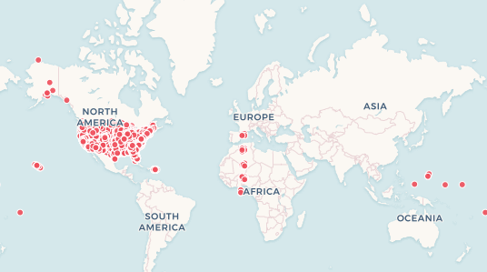

```r
length(table(college$CITY))
```

```
## [1] 2242
```

The only location related attribute that will be used is “STABBR”, which is the state code. “UNITID” will be used because institution names can occur more than one time if one institution has more than one campus.

```r
college_data <- college[,-c(2,3,5,6,7)]
head(college_data)
```

```
## # A tibble: 6 x 22
##   UNITID STABBR LOCALE CONTROL DISTANCEONLY PREDDEG TUITFTE AVGFACSAL
##    <dbl> <chr>   <dbl>   <dbl> <lgl>          <dbl>   <dbl>     <dbl>
## 1 100654 AL         12       1 FALSE              3    9063      7079
## 2 100663 AL         12       1 FALSE              3    9033     10170
## 3 100937 AL         12       2 FALSE              3   11928      7513
## 4 104717 AZ         11       3 FALSE              3   10748      5473
## 5 142887 IL         11       3 FALSE              3   24434      4136
## 6 143048 IL         11       2 FALSE              3   28093      9208
## # ... with 14 more variables: ADM_RATE <dbl>, SAT_AVG <dbl>, UGDS <dbl>,
## #   UGDS_WHITE <dbl>, UGDS_BLACK <dbl>, UGDS_HISP <dbl>, UGDS_ASIAN <dbl>,
## #   IND_INC_PCT_LO <chr>, IND_INC_PCT_M1 <chr>, IND_INC_PCT_M2 <chr>,
## #   IND_INC_PCT_H1 <chr>, IND_INC_PCT_H2 <chr>, PCTFLOAN <dbl>,
## #   GRAD_DEBT_MDN <chr>
```

```r
dim(data.frame(table(college_data$STABBR)))
```

```
## [1] 59  2
```

There are 59 state postcode in the data.

Before missing value imputation, we change the class of categorical values:

```r
glimpse(college_data)
```

```
## Observations: 5,709
## Variables: 22
## $ UNITID         <dbl> 100654, 100663, 100937, 104717, 142887, 143048,...
## $ STABBR         <chr> "AL", "AL", "AL", "AZ", "IL", "IL", "IL", "IL",...
## $ LOCALE         <dbl> 12, 12, 12, 11, 11, 11, 13, 21, 21, 32, 13, 32,...
## $ CONTROL        <dbl> 1, 1, 2, 3, 3, 2, 2, 2, 1, 2, 1, 2, 3, 2, 3, 3,...
## $ DISTANCEONLY   <lgl> FALSE, FALSE, FALSE, FALSE, FALSE, FALSE, FALSE...
## $ PREDDEG        <dbl> 3, 3, 3, 3, 3, 3, 3, 3, 1, 4, 2, 3, 2, 3, 1, 1,...
## $ TUITFTE        <dbl> 9063, 9033, 11928, 10748, 24434, 28093, 17277, ...
## $ AVGFACSAL      <dbl> 7079, 10170, 7513, 5473, 4136, 9208, 7186, 7064...
## $ ADM_RATE       <dbl> 0.8989, 0.8673, 0.6422, 0.5480, 0.9300, 0.7184,...
## $ SAT_AVG        <dbl> 823, 1146, 1177, NA, NA, 1065, NA, 1011, NA, NA...
## $ UGDS           <dbl> 4051, 11200, 1181, 34643, 406, 2641, 2504, 3236...
## $ UGDS_WHITE     <dbl> 0.0279, 0.5987, 0.8103, 0.4427, 0.5394, 0.4559,...
## $ UGDS_BLACK     <dbl> 0.9501, 0.2590, 0.0940, 0.2075, 0.1232, 0.0299,...
## $ UGDS_HISP      <dbl> 0.0089, 0.0258, 0.0305, 0.1452, 0.2488, 0.0629,...
## $ UGDS_ASIAN     <dbl> 0.0022, 0.0518, 0.0390, 0.0437, 0.0394, 0.1253,...
## $ IND_INC_PCT_LO <chr> "0.947019868", "0.701354241", "1", "0.644696731...
## $ IND_INC_PCT_M1 <chr> "PrivacySuppressed", "0.142551675", "0", "0.129...
## $ IND_INC_PCT_M2 <chr> "PrivacySuppressed", "0.086956522", "0", "0.110...
## $ IND_INC_PCT_H1 <chr> "PrivacySuppressed", "0.05274412", "0", "0.0728...
## $ IND_INC_PCT_H2 <chr> "0", "0.016393443", "0", "0.042993798", "0", "P...
## $ PCTFLOAN       <dbl> 0.8204, 0.5397, 0.4939, 0.6248, 0.8403, 0.4835,...
## $ GRAD_DEBT_MDN  <chr> "33611.5", "23117", "27000", "18750", "27000", ...
```

```r
shouldBeCategorical <- c('STABBR', 'LOCALE', 'CONTROL', 'DISTANCEONLY', 'PREDDEG')
for(v in shouldBeCategorical) {
  college_data[[v]] <- as.factor(college_data[[v]])
}
```

In the “IND_INC_PCT_L0”, “IND_INC_PCT_M1”, “IND_INC_PCT_M2”, “IND_INC_PCT_H1” and “IND_INC_PCT_H2” attributes, there is a value named as “PrivacySuppressed”. This value is converted into NA. On the other hand, these attributes’ class should be numerical.

```r
college_data[college_data == "PrivacySuppressed"] <- NA
shouldBeNumerical <- c('IND_INC_PCT_LO', 'IND_INC_PCT_M1', 'IND_INC_PCT_M2', 'IND_INC_PCT_H1','IND_INC_PCT_H2', 'GRAD_DEBT_MDN')
for(v in shouldBeNumerical) {
  college_data[[v]] <- as.numeric(as.character(college_data[[v]]))
}
glimpse(college_data)
```

```
## Observations: 5,709
## Variables: 22
## $ UNITID         <dbl> 100654, 100663, 100937, 104717, 142887, 143048,...
## $ STABBR         <fct> AL, AL, AL, AZ, IL, IL, IL, IL, IL, IN, IL, IL,...
## $ LOCALE         <fct> 12, 12, 12, 11, 11, 11, 13, 21, 21, 32, 13, 32,...
## $ CONTROL        <fct> 1, 1, 2, 3, 3, 2, 2, 2, 1, 2, 1, 2, 3, 2, 3, 3,...
## $ DISTANCEONLY   <fct> FALSE, FALSE, FALSE, FALSE, FALSE, FALSE, FALSE...
## $ PREDDEG        <fct> 3, 3, 3, 3, 3, 3, 3, 3, 1, 4, 2, 3, 2, 3, 1, 1,...
## $ TUITFTE        <dbl> 9063, 9033, 11928, 10748, 24434, 28093, 17277, ...
## $ AVGFACSAL      <dbl> 7079, 10170, 7513, 5473, 4136, 9208, 7186, 7064...
## $ ADM_RATE       <dbl> 0.8989, 0.8673, 0.6422, 0.5480, 0.9300, 0.7184,...
## $ SAT_AVG        <dbl> 823, 1146, 1177, NA, NA, 1065, NA, 1011, NA, NA...
## $ UGDS           <dbl> 4051, 11200, 1181, 34643, 406, 2641, 2504, 3236...
## $ UGDS_WHITE     <dbl> 0.0279, 0.5987, 0.8103, 0.4427, 0.5394, 0.4559,...
## $ UGDS_BLACK     <dbl> 0.9501, 0.2590, 0.0940, 0.2075, 0.1232, 0.0299,...
## $ UGDS_HISP      <dbl> 0.0089, 0.0258, 0.0305, 0.1452, 0.2488, 0.0629,...
## $ UGDS_ASIAN     <dbl> 0.0022, 0.0518, 0.0390, 0.0437, 0.0394, 0.1253,...
## $ IND_INC_PCT_LO <dbl> 0.9470199, 0.7013542, 1.0000000, 0.6446967, 1.0...
## $ IND_INC_PCT_M1 <dbl> NA, 0.14255167, 0.00000000, 0.12905147, 0.00000...
## $ IND_INC_PCT_M2 <dbl> NA, 0.08695652, 0.00000000, 0.11041032, 0.00000...
## $ IND_INC_PCT_H1 <dbl> NA, 0.05274412, 0.00000000, 0.07284768, 0.00000...
## $ IND_INC_PCT_H2 <dbl> 0.000000000, 0.016393443, 0.000000000, 0.042993...
## $ PCTFLOAN       <dbl> 0.8204, 0.5397, 0.4939, 0.6248, 0.8403, 0.4835,...
## $ GRAD_DEBT_MDN  <dbl> 33611.5, 23117.0, 27000.0, 18750.0, 27000.0, 25...
```

Checking the missing values:

```r
sapply(college_data, function(x) sum(is.na(x)))
```

```
##         UNITID         STABBR         LOCALE        CONTROL   DISTANCEONLY
##              0              0             10              0              7
##        PREDDEG        TUITFTE      AVGFACSAL       ADM_RATE        SAT_AVG
##              0             12           2066           3823           4338
##           UGDS     UGDS_WHITE     UGDS_BLACK      UGDS_HISP     UGDS_ASIAN
##            271            271            271            271            271
## IND_INC_PCT_LO IND_INC_PCT_M1 IND_INC_PCT_M2 IND_INC_PCT_H1 IND_INC_PCT_H2
##           1885           2738           3420           4164           3637
##       PCTFLOAN  GRAD_DEBT_MDN
##            284           1162
```

For missing value imputation, “missMDA” package will be used. Based on dimensionality reduction methods, this packae succesfully imputes datasets with quantitative, categorical and mixed variables. Indeed, it imputes data with principal component methods that take into account the similarities between the observations and the relationships between variables. It has proven to be really competitive in terms of quality of the prediction compared to the state of art methods.

For leave-one-out cross-validation (method.cv=“loo”), each cell of the data matrix is alternatively removed and predicted with a FAMD model using ncp.min to ncp.max dimensions. The number of components which leads to the smallest mean square error of prediction (MSEP) is retained. For the Kfold cross-validation (method.cv=“Kfold”), pNA percentage of missing values is inserted at random in the data matrix and predicted with a FAMD model using ncp.min to ncp.max dimensions. This process is repeated nbsim times. The number of components which leads to the smallest MSEP is retained. More precisely, for both cross-validation methods, the missing entries are predicted using the imputeFAMD function, it means using it means using the regularized iterative FAMD algorithm (method=“Regularized”) or the iterative FAMD algorithm (method=“EM”). The regularized version is more appropriate to avoid overfitting issues.

# np <- estim_ncpFAMD(college)#3- takes too much time to run

```r
library(missMDA)
res.impute <- imputeFAMD(college_data, ncp = 3)
```

As default, method is “regularized” in “imputeFAMD” function. This is to avoid the overfitting problems. In the regularized algorithm, the singular values of FAMD are shrinked.

```r
second_part_data <-res.impute$completeObs[,-c(1:6)]
first_part_data <- college_data[,c(1:6)]
college_data <- cbind(first_part_data, second_part_data)
head(college_data)
```

```
##   UNITID STABBR LOCALE CONTROL DISTANCEONLY PREDDEG TUITFTE AVGFACSAL
## 1 100654     AL     12       1        FALSE       3    9063      7079
## 2 100663     AL     12       1        FALSE       3    9033     10170
## 3 100937     AL     12       2        FALSE       3   11928      7513
## 4 104717     AZ     11       3        FALSE       3   10748      5473
## 5 142887     IL     11       3        FALSE       3   24434      4136
## 6 143048     IL     11       2        FALSE       3   28093      9208
##   ADM_RATE   SAT_AVG  UGDS UGDS_WHITE UGDS_BLACK UGDS_HISP UGDS_ASIAN
## 1   0.8989  823.0000  4051     0.0279     0.9501    0.0089     0.0022
## 2   0.8673 1146.0000 11200     0.5987     0.2590    0.0258     0.0518
## 3   0.6422 1177.0000  1181     0.8103     0.0940    0.0305     0.0390
## 4   0.5480 1106.0456 34643     0.4427     0.2075    0.1452     0.0437
## 5   0.9300  979.2571   406     0.5394     0.1232    0.2488     0.0394
## 6   0.7184 1065.0000  2641     0.4559     0.0299    0.0629     0.1253
##   IND_INC_PCT_LO IND_INC_PCT_M1 IND_INC_PCT_M2 IND_INC_PCT_H1
## 1      0.9470199      0.1096728     0.05883797     0.01819590
## 2      0.7013542      0.1425517     0.08695652     0.05274412
## 3      1.0000000      0.0000000     0.00000000     0.00000000
## 4      0.6446967      0.1290515     0.11041032     0.07284768
## 5      1.0000000      0.0000000     0.00000000     0.00000000
## 6      0.9099099      0.1331910     0.08120773     0.03630526
##   IND_INC_PCT_H2 PCTFLOAN GRAD_DEBT_MDN
## 1     0.00000000   0.8204       33611.5
## 2     0.01639344   0.5397       23117.0
## 3     0.00000000   0.4939       27000.0
## 4     0.04299380   0.6248       18750.0
## 5     0.00000000   0.8403       27000.0
## 6     0.01590986   0.4835       25000.0
```

```r
college_data$LOCALE[is.na(college_data$LOCALE)]<-21
college_data$DISTANCEONLY[is.na(college_data$DISTANCEONLY)]<-FALSE
```

Choosing the attributes we are interested:

```r
names(college_data)
```

```
##  [1] "UNITID"         "STABBR"         "LOCALE"         "CONTROL"
##  [5] "DISTANCEONLY"   "PREDDEG"        "TUITFTE"        "AVGFACSAL"
##  [9] "ADM_RATE"       "SAT_AVG"        "UGDS"           "UGDS_WHITE"
## [13] "UGDS_BLACK"     "UGDS_HISP"      "UGDS_ASIAN"     "IND_INC_PCT_LO"
## [17] "IND_INC_PCT_M1" "IND_INC_PCT_M2" "IND_INC_PCT_H1" "IND_INC_PCT_H2"
## [21] "PCTFLOAN"       "GRAD_DEBT_MDN"
```

```r
student_data <- college_data[,c(1,2,3,5,6,7,9,10,11)]
head(student_data)
```

```
##   UNITID STABBR LOCALE DISTANCEONLY PREDDEG TUITFTE ADM_RATE   SAT_AVG
## 1 100654     AL     12        FALSE       3    9063   0.8989  823.0000
## 2 100663     AL     12        FALSE       3    9033   0.8673 1146.0000
## 3 100937     AL     12        FALSE       3   11928   0.6422 1177.0000
## 4 104717     AZ     11        FALSE       3   10748   0.5480 1106.0456
## 5 142887     IL     11        FALSE       3   24434   0.9300  979.2571
## 6 143048     IL     11        FALSE       3   28093   0.7184 1065.0000
##    UGDS
## 1  4051
## 2 11200
## 3  1181
## 4 34643
## 5   406
## 6  2641
```

At the first thought, one can think that Euclidean distance is a good choice to group observations. However, it is only valid for continuous variables, thus it is not applicable here. Gower distance is a distance metric that can handle mixed data types. For each variable type, a particular distance metric that works well for that type is used and scaled to fall between 0 and 1. Then, a linear combination is calculated to create the final distance matrix. In R, Gower distance can be calculated using “daisy” function.

```r
library(cluster)
disMat<-daisy(student_data[,-1],metric = "gower")
summary(disMat)
```

```
## 16293486 dissimilarities, summarized :
##    Min. 1st Qu.  Median    Mean 3rd Qu.    Max.
##  0.0000  0.2737  0.3877  0.3459  0.4095  0.7148
## Metric :  mixed ;  Types = N, N, N, N, I, I, I, I
## Number of objects : 5709
```

```r
gower_mat<-as.matrix(disMat)
```

Output most similar pair:

```r
student_data[which(gower_mat==min(gower_mat[gower_mat!=min(gower_mat)]),arr.ind = T)[1,],]
```

```
##        UNITID STABBR LOCALE DISTANCEONLY PREDDEG  TUITFTE  ADM_RATE
## 5434 10236809     AL     21        FALSE       0 9748.706 0.8402926
## 5433 10236808     AL     21        FALSE       0 9748.706 0.8402926
##       SAT_AVG      UGDS
## 5434 921.9372 -2896.966
## 5433 921.9372 -2896.966
```

```r
college[5433:5434,]
```

```
## # A tibble: 2 x 27
##    UNITID INSTNM      CITY  STABBR ZIP   LATITUDE LONGITUDE LOCALE CONTROL
##     <dbl> <chr>       <chr> <chr>  <chr>    <dbl>     <dbl>  <dbl>   <dbl>
## 1  1.02e7 Troy Unive~ Troy  AL     3608~       NA        NA     NA       1
## 2  1.02e7 Troy Unive~ Troy  AL     3608~       NA        NA     NA       1
## # ... with 18 more variables: DISTANCEONLY <lgl>, PREDDEG <dbl>,
## #   TUITFTE <dbl>, AVGFACSAL <dbl>, ADM_RATE <dbl>, SAT_AVG <dbl>,
## #   UGDS <dbl>, UGDS_WHITE <dbl>, UGDS_BLACK <dbl>, UGDS_HISP <dbl>,
## #   UGDS_ASIAN <dbl>, IND_INC_PCT_LO <chr>, IND_INC_PCT_M1 <chr>,
## #   IND_INC_PCT_M2 <chr>, IND_INC_PCT_H1 <chr>, IND_INC_PCT_H2 <chr>,
## #   PCTFLOAN <dbl>, GRAD_DEBT_MDN <chr>
```

It is reasonable to have this pair as the most similar one. Because they belong to the same university. Output most dissimilar pair:

```r
student_data[which(gower_mat==max(gower_mat[gower_mat!=max(gower_mat)]),arr.ind = T)[1,],]
```

```
##        UNITID STABBR LOCALE DISTANCEONLY PREDDEG  TUITFTE ADM_RATE
## 5483 48285706     GA     21        FALSE       0 9942.645 1.162390
## 1739   196680     NY     13         TRUE       3 3944.000 0.530416
##        SAT_AVG      UGDS
## 5483  645.8797 -19481.82
## 1739 1176.3218  37440.00
```

```r
college[c(5483,1739),]
```

```
## # A tibble: 2 x 27
##    UNITID INSTNM     CITY   STABBR ZIP   LATITUDE LONGITUDE LOCALE CONTROL
##     <dbl> <chr>      <chr>  <chr>  <chr>    <dbl>     <dbl>  <dbl>   <dbl>
## 1  4.83e7 Georgia M~ Mille~ GA     31061     NA        NA       NA       1
## 2  1.97e5 Excelsior~ Albany NY     1220~     42.7     -73.9     13       2
## # ... with 18 more variables: DISTANCEONLY <lgl>, PREDDEG <dbl>,
## #   TUITFTE <dbl>, AVGFACSAL <dbl>, ADM_RATE <dbl>, SAT_AVG <dbl>,
## #   UGDS <dbl>, UGDS_WHITE <dbl>, UGDS_BLACK <dbl>, UGDS_HISP <dbl>,
## #   UGDS_ASIAN <dbl>, IND_INC_PCT_LO <chr>, IND_INC_PCT_M1 <chr>,
## #   IND_INC_PCT_M2 <chr>, IND_INC_PCT_H1 <chr>, IND_INC_PCT_H2 <chr>,
## #   PCTFLOAN <dbl>, GRAD_DEBT_MDN <chr>
```

The pam algorithm is a clustering approach related to k-means clustering for partitioning a data set into k groups or clusters. In k-medoids clustering, each cluster is represented by one of the data point in the cluster. These points are named cluster medoids. The term medoid refers to an object within a cluster for which average dissimilarity between it and all the other the members of the cluster is minimal. It corresponds to the most centrally located point in the cluster. These objects (one per cluster) can be considered as a representative example of the members of that cluster which may be useful in some situations. Recall that, in k-means clustering, the center of a given cluster is calculated as the mean value of all the data points in the cluster.

K-medoid is a robust alternative to k-means clustering. This means that, the algorithm is less sensitive to noise and outliers, compared to k-means, because it uses medoids as cluster centers instead of means (used in k-means).

The k-medoids algorithm requires the user to specify k, the number of clusters to be generated (like in k-means clustering). A useful approach to determine the optimal number of clusters is the silhouette method. Silhouette refers to a method of interpretation and validation of consistency within clusters of data. The technique provides a graphical representation of how well each object lies within its cluster.

The silhouette value is a measure of how similar an object is to its own cluster (cohesion) compared to other clusters (separation). The silhouette ranges from ???1 to +1, where a high value indicates that the object is well matched to its own cluster and poorly matched to neighboring clusters. If most objects have a high value, then the clustering configuration is appropriate. If many points have a low or negative value, then the clustering configuration may have too many or too few clusters.

Calculate silhouette width for many k using PAM:

```r
sil_width <- c(NA)
for(i in 2:10){
  pam_fit <- pam(gower_mat, diss=T,k=i)
  sil_width[i]<-pam_fit$silinfo$avg.width
}
```

Plot silhouette width:

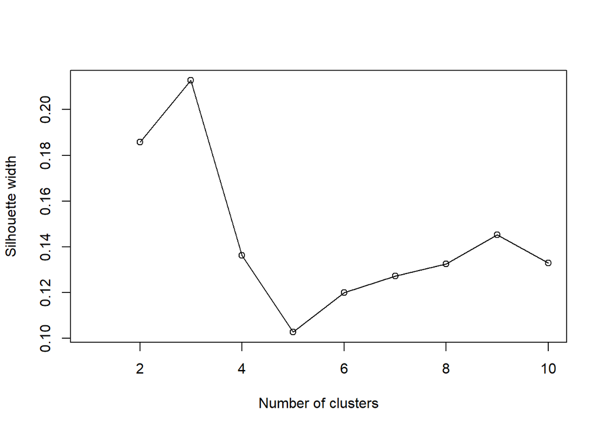

```r
plot(1:10, sil_width, xlab = "Number of clusters", ylab = "Silhouette width")
lines(1:10, sil_width)
```

Since higher is the better, 3 is chosen as the cluster number.

```r
pam_fit <- pam(gower_mat, diss = T, k=3)
pam_results <- student_data %>% dplyr::select(-UNITID) %>% mutate(cluster=pam_fit$clustering) %>% group_by(cluster) %>% do(the_summary=summary(.))
pam_results$the_summary
```

```
## [[1]]
##      STABBR         LOCALE    DISTANCEONLY PREDDEG     TUITFTE
##  NY     : 284   11     :618   FALSE:1937   0:   5   Min.   :     0
##  PA     : 105   13     :277   TRUE :  21   1:  75   1st Qu.:  7681
##  CA     : 100   21     :266                2:  31   Median : 12186
##  IL     :  90   12     :236                3:1694   Mean   : 13546
##  MA     :  82   32     :161                4: 153   3rd Qu.: 17184
##  OH     :  64   33     :123                         Max.   :123492
##  (Other):1233   (Other):277
##     ADM_RATE         SAT_AVG          UGDS            cluster
##  Min.   :0.0000   Min.   : 666   Min.   : -193.3   Min.   :1
##  1st Qu.:0.5730   1st Qu.:1008   1st Qu.:  798.5   1st Qu.:1
##  Median :0.6643   Median :1045   Median : 1986.0   Median :1
##  Mean   :0.6492   Mean   :1060   Mean   : 4405.6   Mean   :1
##  3rd Qu.:0.7407   3rd Qu.:1094   3rd Qu.: 4662.5   3rd Qu.:1
##  Max.   :1.0000   Max.   :1534   Max.   :50919.0   Max.   :1
##
##
## [[2]]
##      STABBR         LOCALE    DISTANCEONLY PREDDEG     TUITFTE
##  CA     : 405   21     :971   FALSE:2524   0:  25   Min.   :     0
##  FL     : 173   13     :344   TRUE :   6   1:2225   1st Qu.:  3347
##  OH     : 145   11     :299                2:  85   Median :  6934
##  PA     : 143   12     :290                3: 115   Mean   :  8136
##  IL     : 102   41     :143                4:  80   3rd Qu.: 10546
##  MO     :  88   33     :140                         Max.   :207213
##  (Other):1474   (Other):343
##     ADM_RATE         SAT_AVG            UGDS             cluster
##  Min.   :0.0000   Min.   : 645.9   Min.   :-19481.8   Min.   :2
##  1st Qu.:0.7129   1st Qu.: 963.9   1st Qu.:    62.0   1st Qu.:2
##  Median :0.7522   Median : 981.1   Median :   144.5   Median :2
##  Mean   :0.7392   Mean   : 987.0   Mean   :   921.7   Mean   :2
##  3rd Qu.:0.7767   3rd Qu.:1001.8   3rd Qu.:   479.5   3rd Qu.:2
##  Max.   :1.1624   Max.   :1483.0   Max.   : 33439.0   Max.   :2
##
##
## [[3]]
##      STABBR        LOCALE    DISTANCEONLY PREDDEG    TUITFTE
##  TX     :213   11     :361   FALSE:1216   0:  6   Min.   :    0
##  CA     : 82   13     :158   TRUE :   5   1:183   1st Qu.: 1653
##  FL     : 53   41     :127                2:962   Median : 3029
##  NC     : 53   12     :123                3: 39   Mean   : 5181
##  NY     : 53   21     :117                4: 31   3rd Qu.: 6772
##  PA     : 52   33     :100                        Max.   :95815
##  (Other):715   (Other):235
##     ADM_RATE         SAT_AVG          UGDS          cluster
##  Min.   :0.0000   Min.   : 755   Min.   : -211   Min.   :3
##  1st Qu.:0.6740   1st Qu.:1001   1st Qu.:  445   1st Qu.:3
##  Median :0.7098   Median :1021   Median : 2167   Median :3
##  Mean   :0.7026   Mean   :1021   Mean   : 4365   Mean   :3
##  3rd Qu.:0.7421   3rd Qu.:1045   3rd Qu.: 5549   3rd Qu.:3
##  Max.   :1.0000   Max.   :1187   Max.   :87017   Max.   :3
##
```

```r
student_data[pam_fit$medoids,]
```

```
##      UNITID STABBR LOCALE DISTANCEONLY PREDDEG TUITFTE  ADM_RATE   SAT_AVG
## 1743 197018     NY     11        FALSE       3   13091 0.6975450 1022.9939
## 4468 444361     CA     21        FALSE       1   11356 0.7374431  979.3618
## 2796 224271     TX     11        FALSE       2    5776 0.6999249 1010.8458
##      UGDS
## 1743 1814
## 4468  103
## 2796  114
```

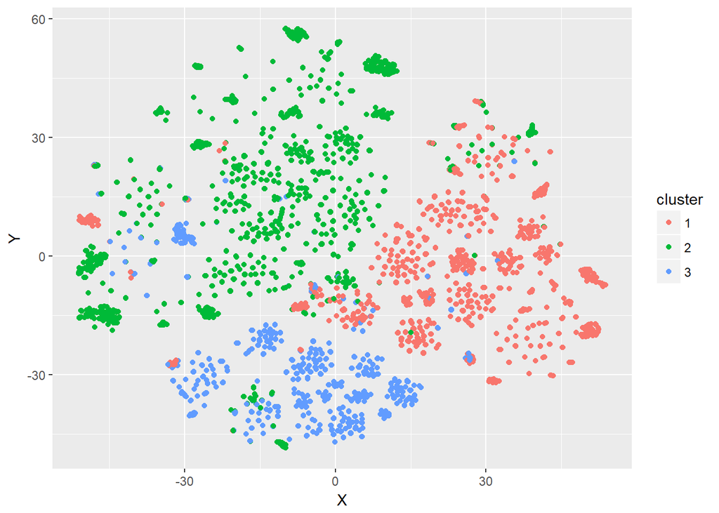

```r
library(ggplot2)
library(Rtsne)
tsne_obj <- Rtsne(gower_mat, is_distance = T)
tsne_data <- tsne_obj$Y %>% data.frame() %>% setNames(c("X","Y")) %>% mutate(cluster=factor(pam_fit$clustering), id=student_data$UNITID)
ggplot(aes(x=X, y=Y), data=tsne_data)+geom_point(aes(color=cluster))
```

# Future Work

I would like to use latitude and longitude information after they are corrected. It will be usefull to see the institution that are close by spherical distance. It can give an idea to a student to enroll.

In this study, the institutions with the same name but different IDs are not touched. I would like to reduce the dimensionality of the data by having only one line for the institutions with the same name. Average methods could be used for the continous variables.

In the dataset provided, there is no information about which university is based on which professionalities (medical, law, etc.) If we have this information, the clustering will make more sense since we will have more clusters.